# Homework_3

This is the link to the repo:https://github.com/YiyiW02/Homework_3

Problem 1: (a)

```r
library(haven)

# Read the two datasets
aux <- read_xpt("AUX_I.XPT")
demo <- read_xpt("DEMO_I.XPT")

# Merge by respondent ID, keeping matched records
nhanes <- merge(aux, demo, by = "SEQN")

# Print the dimensions of the merged dataset
dim(nhanes)
```

```
[1] 4582  119
```

```r
# Check for missing or duplicate respondent IDs
sum(is.na(nhanes$SEQN))
```

```
[1] 0
```

```r
anyDuplicated(nhanes$SEQN)
```

```
[1] 0
```

The merged dataset contains 4,582 observations and 119 variables. There are no missing or duplicate respondent IDs.

```r
# Clean gender variable
nhanes$gender <- factor(
  nhanes$RIAGENDR,
  levels = c(1, 2),
  labels = c("Male", "Female")
)

# Check the cleaned variable
table(nhanes$gender, useNA = "ifany")
```

```
  Male Female
  2176   2406
```

```r
# Clean citizenship status
nhanes$citizenship <- factor(
  nhanes$DMDCITZN,
  levels = c(1, 2),
  labels = c("Citizen", "Non-citizen")
)

# Check the cleaned variable
table(nhanes$citizenship, useNA = "always")
```

```
    Citizen Non-citizen        <NA>
       3684         884          14
```

```r
# Clean number of children aged 5 or younger
nhanes$children <- nhanes$DMDHHSZA

# Check the cleaned variable
table(nhanes$children, useNA = "always")
```

```
   0    1    2    3 <NA>
3463  737  317   65    0
```

```r
# Clean annual household income
# Keep income categories with a clear ordering
income_codes <- c(1:10, 14, 15)

income_labels <- c(
  "$0-$4,999",
  "$5,000-$9,999",
  "$10,000-$14,999",
  "$15,000-$19,999",
  "$20,000-$24,999",
  "$25,000-$34,999",
  "$35,000-$44,999",
  "$45,000-$54,999",
  "$55,000-$64,999",
  "$65,000-$74,999",
  "$75,000-$99,999",
  "$100,000 and over"
)

# Convert income to an ordered factor
# Broad income categories and invalid responses become NA
nhanes$income <- factor(
  nhanes$INDHHIN2,
  levels = income_codes,
  labels = income_labels,
  ordered = TRUE
)

# Check the cleaned income categories
table(nhanes$income, useNA = "always")
```

```
        $0-$4,999     $5,000-$9,999   $10,000-$14,999   $15,000-$19,999
              101               146               233               262
  $20,000-$24,999   $25,000-$34,999   $35,000-$44,999   $45,000-$54,999
              272               461               439               381
  $55,000-$64,999   $65,000-$74,999   $75,000-$99,999 $100,000 and over
              295               244               458               795
             <NA>
              495
```

```r
# Check that income is an ordered factor
is.ordered(nhanes$income)
```

```
[1] TRUE
```

```r
# Display income levels in the correct order
levels(nhanes$income)
```

```
 [1] "$0-$4,999"         "$5,000-$9,999"     "$10,000-$14,999"
 [4] "$15,000-$19,999"   "$20,000-$24,999"   "$25,000-$34,999"
 [7] "$35,000-$44,999"   "$45,000-$54,999"   "$55,000-$64,999"
[10] "$65,000-$74,999"   "$75,000-$99,999"   "$100,000 and over"
```

```r
# Check original household income codes
table(nhanes$INDHHIN2, useNA = "always")
```

```
   1    2    3    4    5    6    7    8    9   10   12   13   14   15   77   99
 101  146  233  262  272  461  439  381  295  244  145   53  458  795   86   63
<NA>
 148
```

```r
# Count records with broad income categories
sum(nhanes$INDHHIN2 %in% c(12, 13))
```

```
[1] 198
```

```r
# Count missing values after cleaning
sum(is.na(nhanes$income))
```

```
[1] 495
```

Annual household income was converted into an ordered factor with 12 income categories. Codes 12 and 13 were treated as missing because they represent broad income ranges that overlap with the more specific categories. Codes 77 and 99 were also treated as missing. This resulted in 495 missing income values, including 198 observations from the two broad income categories.

```r
# Convert ordered income categories to numeric ranks
nhanes$income_num <- as.numeric(nhanes$income)

# Check numeric income values
table(nhanes$income_num, useNA = "always")
```

```
   1    2    3    4    5    6    7    8    9   10   11   12 <NA>
 101  146  233  262  272  461  439  381  295  244  458  795  495
```

```r
# Find variables related to tympanometric width
grep("AUXT", names(nhanes), value = TRUE)
```

```
[1] "AUXTMEPR" "AUXTPVR"  "AUXTWIDR" "AUXTCOMR" "AUXTMEPL" "AUXTPVL"  "AUXTWIDL"
[8] "AUXTCOML"
```

```r
# Check right ear tympanometric width
summary(nhanes$AUXTWIDR)
```

```
   Min. 1st Qu.  Median    Mean 3rd Qu.    Max.    NA's
   8.00   61.00   79.00   84.73   98.00  479.00     433
```

```r
sum(is.na(nhanes$AUXTWIDR))
```

```
[1] 433
```

```r
# Model 1R: Right ear tympanometric width predicted by gender
model_1R <- glm(
  AUXTWIDR ~ gender,
  data = nhanes,
  family = poisson(link = "log")
)

# Display regression results
summary(model_1R)
```

```
Call:
glm(formula = AUXTWIDR ~ gender, family = poisson(link = "log"),
    data = nhanes)

Coefficients:
             Estimate Std. Error  z value Pr(>|z|)
(Intercept)  4.434588   0.002468 1796.797  < 2e-16 ***
genderFemale 0.009264   0.003380    2.741  0.00613 **
---
Signif. codes:  0 '***' 0.001 '**' 0.01 '*' 0.05 '.' 0.1 ' ' 1

(Dispersion parameter for poisson family taken to be 1)

    Null deviance: 70970  on 4148  degrees of freedom
Residual deviance: 70963  on 4147  degrees of freedom
  (433 observations deleted due to missingness)
AIC: 96618

Number of Fisher Scoring iterations: 4
```

```r
# Calculate incidence rate ratios (IRR)
exp(coef(model_1R))
```

```
 (Intercept) genderFemale
   84.317411     1.009307
```

```r
# Model 2R: Right ear with four predictors
model_2R <- glm(
  AUXTWIDR ~ gender + citizenship + children + income_num,
  data = nhanes,
  family = poisson(link = "log")
)

# Display regression results
summary(model_2R)
```

```
Call:
glm(formula = AUXTWIDR ~ gender + citizenship + children + income_num,
    family = poisson(link = "log"), data = nhanes)

Coefficients:
                         Estimate Std. Error z value Pr(>|z|)
(Intercept)             4.4822946  0.0054186 827.209  < 2e-16 ***
genderFemale            0.0148825  0.0035951   4.140 3.48e-05 ***
citizenshipNon-citizen  0.0458588  0.0046104   9.947  < 2e-16 ***
children               -0.0055898  0.0027138  -2.060   0.0394 *
income_num             -0.0079074  0.0005588 -14.152  < 2e-16 ***
---
Signif. codes:  0 '***' 0.001 '**' 0.01 '*' 0.05 '.' 0.1 ' ' 1

(Dispersion parameter for poisson family taken to be 1)

    Null deviance: 62369  on 3704  degrees of freedom
Residual deviance: 62013  on 3700  degrees of freedom
  (877 observations deleted due to missingness)
AIC: 84916

Number of Fisher Scoring iterations: 4
```

```r
# Calculate incidence rate ratios (IRR)
exp(coef(model_2R))
```

```
           (Intercept)           genderFemale citizenshipNon-citizen
            88.4373679              1.0149938              1.0469266
              children             income_num
             0.9944258              0.9921237
```

```r
# Model 1L: Left ear tympanometric width predicted by gender
model_1L <- glm(
  AUXTWIDL ~ gender,
  data = nhanes,
  family = poisson(link = "log")
)

# Display regression results
summary(model_1L)
```

```
Call:
glm(formula = AUXTWIDL ~ gender, family = poisson(link = "log"),
    data = nhanes)

Coefficients:
             Estimate Std. Error  z value Pr(>|z|)
(Intercept)  4.439805   0.002473 1795.263  < 2e-16 ***
genderFemale 0.012952   0.003387    3.824 0.000131 ***
---
Signif. codes:  0 '***' 0.001 '**' 0.01 '*' 0.05 '.' 0.1 ' ' 1

(Dispersion parameter for poisson family taken to be 1)

    Null deviance: 73307  on 4102  degrees of freedom
Residual deviance: 73293  on 4101  degrees of freedom
  (479 observations deleted due to missingness)
AIC: 98685

Number of Fisher Scoring iterations: 4
```

```r
# Calculate incidence rate ratios (IRR)
exp(coef(model_1L))
```

```
 (Intercept) genderFemale
   84.758424     1.013037
```

```r
# Model 2L: Left ear with four predictors
model_2L <- glm(
  AUXTWIDL ~ gender + citizenship + children + income_num,
  data = nhanes,
  family = poisson(link = "log")
)

# Display regression results
summary(model_2L)
```

```
Call:
glm(formula = AUXTWIDL ~ gender + citizenship + children + income_num,
    family = poisson(link = "log"), data = nhanes)

Coefficients:
                         Estimate Std. Error z value Pr(>|z|)
(Intercept)             4.4866264  0.0054292 826.395  < 2e-16 ***
genderFemale            0.0185727  0.0035996   5.160 2.47e-07 ***
citizenshipNon-citizen  0.0215482  0.0046454   4.639 3.51e-06 ***
children               -0.0171863  0.0027277  -6.301 2.96e-10 ***
income_num             -0.0065522  0.0005585 -11.732  < 2e-16 ***
---
Signif. codes:  0 '***' 0.001 '**' 0.01 '*' 0.05 '.' 0.1 ' ' 1

(Dispersion parameter for poisson family taken to be 1)

    Null deviance: 64149  on 3664  degrees of freedom
Residual deviance: 63916  on 3660  degrees of freedom
  (917 observations deleted due to missingness)
AIC: 86598

Number of Fisher Scoring iterations: 4
```

```r
# Calculate incidence rate ratios (IRR)
exp(coef(model_2L))
```

```
           (Intercept)           genderFemale citizenshipNon-citizen
            88.8212935              1.0187463              1.0217820
              children             income_num
             0.9829605              0.9934692
```

```r
# Combine incidence risk ratios from all four models
terms <- c(
  "(Intercept)",
  "genderFemale",
  "citizenshipNon-citizen",
  "children",
  "income_num"
)

irr_table <- data.frame(
  Predictor = c(
    "Intercept",
    "Female",
    "Non-citizen",
    "Children",
    "Income"
  ),
  "1R" = round(exp(coef(model_1R)[terms]), 3),
  "2R" = round(exp(coef(model_2R)[terms]), 3),
  "1L" = round(exp(coef(model_1L)[terms]), 3),
  "2L" = round(exp(coef(model_2L)[terms]), 3),
  check.names = FALSE
)

# Display the IRR table
knitr::kable(
  irr_table,
  row.names = FALSE,
  caption = "Incidence Rate Ratios (IRR) for Four Poisson Models"
)
```

Incidence Rate Ratios (IRR) for Four Poisson Models

| Predictor | 1R | 2R | 1L | 2L |
| --- | --- | --- | --- | --- |
| Intercept | 84.317 | 88.437 | 84.758 | 88.821 |
| Female | 1.009 | 1.015 | 1.013 | 1.019 |
| Non-citizen | NA | 1.047 | NA | 1.022 |
| Children | NA | 0.994 | NA | 0.983 |
| Income | NA | 0.992 | NA | 0.993 |

```r
# Calculate model statistics
model_stats <- data.frame(
  Model = c("1R", "2R", "1L", "2L"),
  Sample_Size = c(
    nobs(model_1R),
    nobs(model_2R),
    nobs(model_1L),
    nobs(model_2L)
  ),
  Pseudo_R2 = round(c(
    1 - model_1R$deviance / model_1R$null.deviance,
    1 - model_2R$deviance / model_2R$null.deviance,
    1 - model_1L$deviance / model_1L$null.deviance,
    1 - model_2L$deviance / model_2L$null.deviance
  ), 4),
  AIC = round(c(
    AIC(model_1R),
    AIC(model_2R),
    AIC(model_1L),
    AIC(model_2L)
  ), 2)
)

# Display the model statistics
knitr::kable(
  model_stats,
  row.names = FALSE,
  col.names = c("Model", "Sample Size", "Pseudo-R²", "AIC"),
  caption = "Poisson Regression Model Statistics"
)
```

Poisson Regression Model Statistics

| Model | Sample Size | Pseudo-R² | AIC |
| --- | --- | --- | --- |
| 1R | 4149 | 0.0001 | 96618.48 |
| 2R | 3705 | 0.0057 | 84916.04 |
| 1L | 4103 | 0.0002 | 98685.15 |
| 2L | 3665 | 0.0036 | 86597.96 |

The IRRs represent the multiplicative effects of predictors on the expected tympanometric width. Annual household income was represented by numeric ranks from 1 to 12, with higher values indicating higher income categories. Pseudo-R² was calculated as 1 - residual deviance / null deviance. The low pseudo-R² values suggest that the models explain only a small proportion of the null deviance. NA indicates that a predictor was not included in the model. The models have different sample sizes because observations with missing values were excluded. Therefore, AIC values should be compared cautiously across models fitted to different observations.

```r
# Test 1: Gender difference in IRR using Model 2L
# Extract the gender coefficient and standard error
beta <- coef(summary(model_2L))["genderFemale", "Estimate"]
se <- coef(summary(model_2L))["genderFemale", "Std. Error"]

# Calculate the Wald test statistic and p-value
z <- beta / se
p_value <- 2 * pnorm(-abs(z))

# Display the test results
cat("Female IRR:", exp(beta), "\n")
```

```
Female IRR: 1.018746
```

```r
cat("Z statistic:", z, "\n")
```

```
Z statistic: 5.159705
```

```r
cat("P-value:", p_value, "\n")
```

```
P-value: 2.473393e-07
```

```r
# Test 2: Compare predicted left-ear tympanometric width
# Create two respondents with the same covariates
new_data <- data.frame(
  gender = factor(
    c("Male", "Female"),
    levels = levels(nhanes$gender)
  ),
  citizenship = factor(
    c("Citizen", "Citizen"),
    levels = levels(nhanes$citizenship)
  ),
  children = c(0, 0),
  income_num = c(6, 6)
)

# Predict left-ear tympanometric width
predicted <- predict(
  model_2L,
  newdata = new_data,
  type = "response"
)

# Compare the predicted values
predicted_values <- data.frame(
  Gender = c("Male", "Female"),
  Predicted_Width = round(predicted, 3)
)

knitr::kable(
  predicted_values,
  row.names = FALSE,
  col.names = c("Gender", "Predicted Width"),
  caption = "Predicted Left-Ear Tympanometric Width"
)
```

Predicted Left-Ear Tympanometric Width

| Gender | Predicted Width |
| --- | --- |
| Male | 85.397 |
| Female | 86.998 |

```r
# Calculate the difference between females and males
difference <- predicted[2] - predicted[1]
cat("Predicted difference:", difference, "\n")
```

```
Predicted difference: 1.60088
```

```r
# Under the log-link model, equality of predicted means
# is equivalent to a gender IRR of 1.
cat("Z statistic:", z, "\n")
```

```
Z statistic: 5.159705
```

```r
cat("P-value:", p_value, "\n")
```

```
P-value: 2.473393e-07
```

For the IRR test, the null hypothesis is that the female-to-male IRR equals 1, while the alternative hypothesis is that it differs from 1. For the predicted width test, the null hypothesis is that males and females have equal predicted left-ear tympanometric widths, holding other predictors constant, while the alternative hypothesis is that their predicted widths differ. Using Model 2L, the Wald test gives a z-value of 5.160 and a p-value of 2.47e-07. Since the p-value is below 0.05, we reject the null hypothesis that the female-to-male IRR equals 1. The estimated IRR is 1.0187, suggesting a 1.87% higher expected left-ear tympanometric width for females, holding other predictors constant. For a citizen with no young children and income level 6, the predicted width is 85.397 for males and 86.998 for females, a difference of approximately 1.601. The test of equal predicted means has the same p-value because it is equivalent to testing whether the gender coefficient equals zero under this model. However, the large residual deviance relative to the residual degrees of freedom suggests substantial overdispersion, so the Poisson-based p-values should be interpreted with caution.

Problem 2:

```r
# Load required packages
library(DBI)
library(RSQLite)
library(microbenchmark)

# Connect to the Sakila database
con <- dbConnect(
  SQLite(),
  dbname = "sakila_master.db"
)

# List all tables in the database
dbListTables(con)
```

```
 [1] "actor"                  "address"                "category"
 [4] "city"                   "country"                "customer"
 [7] "customer_list"          "film"                   "film_actor"
[10] "film_category"          "film_list"              "film_text"
[13] "inventory"              "language"               "payment"
[16] "rental"                 "sales_by_film_category" "sales_by_store"
[19] "staff"                  "staff_list"             "store"
```

```r
# Check the structure of the customer table
dbListFields(con, "customer")
```

```
[1] "customer_id" "store_id"    "first_name"  "last_name"   "email"
[6] "address_id"  "active"      "create_date" "last_update"
```

```r
# Preview the first six rows
head(dbReadTable(con, "customer"))
```

```
  customer_id store_id first_name last_name                               email
1           1        1       MARY     SMITH       MARY.SMITH@sakilacustomer.org
2           2        1   PATRICIA   JOHNSON PATRICIA.JOHNSON@sakilacustomer.org
3           3        1      LINDA  WILLIAMS   LINDA.WILLIAMS@sakilacustomer.org
4           4        2    BARBARA     JONES    BARBARA.JONES@sakilacustomer.org
5           5        1  ELIZABETH     BROWN  ELIZABETH.BROWN@sakilacustomer.org
6           6        2   JENNIFER     DAVIS   JENNIFER.DAVIS@sakilacustomer.org
  address_id active             create_date         last_update
1          5      1 2006-02-14 22:04:36.000 2020-12-23 07:15:11
2          6      1 2006-02-14 22:04:36.000 2020-12-23 07:15:11
3          7      1 2006-02-14 22:04:36.000 2020-12-23 07:15:11
4          8      1 2006-02-14 22:04:36.000 2020-12-23 07:15:11
5          9      1 2006-02-14 22:04:36.000 2020-12-23 07:15:11
6         10      1 2006-02-14 22:04:36.000 2020-12-23 07:15:11
```

```r
# Method 1: Extract customer data using SQL
customers <- dbGetQuery(
  con,
  "SELECT store_id, customer_id, active FROM customer"
)
# Convert active status to numeric
customers$active <- as.numeric(customers$active)

# Count total customers and active customers by store
total_customers <- aggregate(
  customer_id ~ store_id,
  data = customers,
  FUN = length
)

# Count active customers by store
active_customers <- aggregate(
  active ~ store_id,
  data = customers,
  FUN = sum
)

# Combine the results
result_r <- merge(
  total_customers,
  active_customers,
  by = "store_id"
)

# Rename columns
names(result_r) <- c(
  "Store",
  "Total_Customers",
  "Active_Customers"
)

# Calculate the percentage of active customers
result_r$Active_Percentage <- round(
  result_r$Active_Customers / result_r$Total_Customers * 100,
  2
)

# Display results
knitr::kable(
  result_r,
  row.names = FALSE,
  col.names = c(
    "Store",
    "Total Customers",
    "Active Customers",
    "Active Percentage (%)"
  ),
  caption = "Customer Activity by Store (R Method)"
)
```

Customer Activity by Store (R Method)

| Store | Total Customers | Active Customers | Active Percentage (%) |
| --- | --- | --- | --- |
| 1 | 326 | 318 | 97.55 |
| 2 | 273 | 266 | 97.44 |

```r
# Method 2: Calculate results directly using SQL
result_sql <- dbGetQuery(
  con,
  "
  SELECT
    store_id AS Store,
    COUNT(*) AS Total_Customers,
    SUM(CAST(active AS INTEGER)) AS Active_Customers,
    ROUND(
      100.0 * SUM(CAST(active AS INTEGER)) / COUNT(*),
      2
    ) AS Active_Percentage
  FROM customer
  GROUP BY store_id
  ORDER BY store_id
  "
)

# Display SQL results
knitr::kable(
  result_sql,
  row.names = FALSE,
  col.names = c(
    "Store",
    "Total Customers",
    "Active Customers",
    "Active Percentage (%)"
  ),
  caption = "Customer Activity by Store (SQL Method)"
)
```

Customer Activity by Store (SQL Method)

| Store | Total Customers | Active Customers | Active Percentage (%) |
| --- | --- | --- | --- |
| 1 | 326 | 318 | 97.55 |
| 2 | 273 | 266 | 97.44 |

```r
# Compare the performance of R and SQL methods
benchmark_a <- microbenchmark(
  R_Method = {
    customers <- dbGetQuery(
      con,
      "SELECT store_id, customer_id, active FROM customer"
    )

    customers$active <- as.numeric(customers$active)

    total_customers <- aggregate(
      customer_id ~ store_id,
      data = customers,
      FUN = length
    )

    active_customers <- aggregate(
      active ~ store_id,
      data = customers,
      FUN = sum
    )

    result_r <- merge(
      total_customers,
      active_customers,
      by = "store_id"
    )

    names(result_r) <- c(
      "Store",
      "Total_Customers",
      "Active_Customers"
    )

    result_r$Active_Percentage <- round(
      100 * result_r$Active_Customers /
        result_r$Total_Customers,
      2
    )
  },

  SQL_Method = {
    result_sql <- dbGetQuery(
      con,
      "
      SELECT
        store_id AS Store,
        COUNT(*) AS Total_Customers,
        SUM(CAST(active AS INTEGER)) AS Active_Customers,
        ROUND(
          100.0 * SUM(CAST(active AS INTEGER)) / COUNT(*),
          2
        ) AS Active_Percentage
      FROM customer
      GROUP BY store_id
      ORDER BY store_id
      "
    )
  },

  times = 100
)
# Display benchmark results
summary(benchmark_a)
```

```
        expr      min       lq      mean    median        uq      max neval
1   R_Method 1141.932 1173.153 1259.5836 1194.1660 1255.9940 3559.661   100
2 SQL_Method  184.623  202.827  217.5271  217.2385  226.5045  296.676   100
```

```r
# Check whether the two methods return the same results
all.equal(
  result_r$Store,
  result_sql$Store
)
```

```
[1] TRUE
```

```r
all.equal(
  result_r$Total_Customers,
  result_sql$Total_Customers
)
```

```
[1] TRUE
```

```r
all.equal(
  result_r$Active_Customers,
  result_sql$Active_Customers
)
```

```
[1] TRUE
```

```r
all.equal(
  result_r$Active_Percentage,
  result_sql$Active_Percentage
)
```

```
[1] TRUE
```

Both methods produced the same results. Store 1 has 326 customers, with 97.55% active, while Store 2 has 273 customers, with 97.44% active. The microbenchmark results show that the SQL method was faster. The median execution time was 217.24 μs for SQL and 1194.17 μs for R. This is because SQL performs the aggregation directly in the database, while the R method requires extracting and processing the data in R.

```r
# Check the fields needed for staff and country information
dbListFields(con, "staff")
```

```
 [1] "staff_id"    "first_name"  "last_name"   "address_id"  "picture"
 [6] "email"       "store_id"    "active"      "username"    "password"
[11] "last_update"
```

```r
dbListFields(con, "address")
```

```
[1] "address_id"  "address"     "address2"    "district"    "city_id"
[6] "postal_code" "phone"       "last_update"
```

```r
dbListFields(con, "city")
```

```
[1] "city_id"     "city"        "country_id"  "last_update"
```

```r
dbListFields(con, "country")
```

```
[1] "country_id"  "country"     "last_update"
```

```r
# Method 1: Extract tables using SQL
staff <- dbGetQuery(
  con,
  "SELECT staff_id, first_name, last_name, address_id FROM staff"
)

address <- dbGetQuery(
  con,
  "SELECT address_id, city_id FROM address"
)

city <- dbGetQuery(
  con,
  "SELECT city_id, country_id FROM city"
)

country <- dbGetQuery(
  con,
  "SELECT country_id, country FROM country"
)

# Merge staff with address
staff_address <- merge(
  staff, address,
  by = "address_id"
)

# Merge with city
staff_city <- merge(
  staff_address, city,
  by = "city_id"
)

# Merge with country
staff_country <- merge(
  staff_city, country,
  by = "country_id"
)

# Create full names and select final columns
result_r_b <- data.frame(
  Staff_Name = paste(
    staff_country$first_name,
    staff_country$last_name
  ),
  Country = staff_country$country
)

# Display results
knitr::kable(
  result_r_b,
  row.names = FALSE,
  col.names = c("Staff Name", "Country"),
  caption = "Staff Names and Countries (R Method)"
)
```

Staff Names and Countries (R Method)

| Staff Name | Country |
| --- | --- |
| Jon Stephens | Australia |
| Mike Hillyer | Canada |

```r
# Method 2: Join tables directly using SQL
result_sql_b <- dbGetQuery(
  con,
  "
  SELECT
    staff.first_name || ' ' || staff.last_name AS Staff_Name,
    country.country AS Country
  FROM staff
  JOIN address
    ON staff.address_id = address.address_id
  JOIN city
    ON address.city_id = city.city_id
  JOIN country
    ON city.country_id = country.country_id
  ORDER BY staff.staff_id
  "
)

# Display SQL results
knitr::kable(
  result_sql_b,
  row.names = FALSE,
  col.names = c("Staff Name", "Country"),
  caption = "Staff Names and Countries (SQL Method)"
)
```

Staff Names and Countries (SQL Method)

| Staff Name | Country |
| --- | --- |
| Mike Hillyer | Canada |
| Jon Stephens | Australia |

```r
# Compare R and SQL methods
benchmark_b <- microbenchmark(
  R_Method = {
    staff <- dbGetQuery(
      con,
      "SELECT staff_id, first_name, last_name, address_id FROM staff"
    )

    address <- dbGetQuery(
      con,
      "SELECT address_id, city_id FROM address"
    )

    city <- dbGetQuery(
      con,
      "SELECT city_id, country_id FROM city"
    )

    country <- dbGetQuery(
      con,
      "SELECT country_id, country FROM country"
    )

    staff_address <- merge(staff, address, by = "address_id")
    staff_city <- merge(staff_address, city, by = "city_id")
    staff_country <- merge(staff_city, country, by = "country_id")

    result_r_b <- data.frame(
      Staff_Name = paste(
        staff_country$first_name,
        staff_country$last_name
      ),
      Country = staff_country$country
    )
  },

  SQL_Method = {
    result_sql_b <- dbGetQuery(
      con,
      "
      SELECT
        staff.first_name || ' ' || staff.last_name AS Staff_Name,
        country.country AS Country
      FROM staff
      JOIN address
        ON staff.address_id = address.address_id
      JOIN city
        ON address.city_id = city.city_id
      JOIN country
        ON city.country_id = country.country_id
      ORDER BY staff.staff_id
      "
    )
  },

  times = 100
)

# Display benchmark results
summary(benchmark_b)
```

```
        expr      min       lq      mean   median        uq      max neval
1   R_Method 1275.674 1306.465 1381.8894 1321.020 1392.5240 3106.775   100
2 SQL_Method  113.406  127.182  138.5985  136.694  147.1285  198.850   100
```

```r
# Sort both results by staff name
r_check_b <- result_r_b[
  order(result_r_b$Staff_Name),
]

sql_check_b <- result_sql_b[
  order(result_sql_b$Staff_Name),
]

# Check whether staff names and countries match
all.equal(
  unname(r_check_b$Staff_Name),
  unname(sql_check_b$Staff_Name)
)
```

```
[1] TRUE
```

```r
all.equal(
  unname(r_check_b$Country),
  unname(sql_check_b$Country)
)
```

```
[1] TRUE
```

```r
# Show benchmark results with time units
print(benchmark_b)
```

```
Unit: microseconds
       expr      min       lq      mean   median        uq      max neval
   R_Method 1275.674 1306.465 1381.8894 1321.020 1392.5240 3106.775   100
 SQL_Method  113.406  127.182  138.5985  136.694  147.1285  198.850   100
```

Both methods returned the same two staff members: Mike Hillyer from Canada and Jon Stephens from Australia. The SQL method was faster than the R method. The median execution time was 136.69 μs for SQL and 1321.02 μs for R. This is because SQL performs the joins directly in the database, while the R method requires extracting four tables and merging them in R.

```r
# Check the fields needed for film rental payments
dbListFields(con, "film")
```

```
 [1] "film_id"              "title"                "description"
 [4] "release_year"         "language_id"          "original_language_id"
 [7] "rental_duration"      "rental_rate"          "length"
[10] "replacement_cost"     "rating"               "special_features"
[13] "last_update"
```

```r
dbListFields(con, "inventory")
```

```
[1] "inventory_id" "film_id"      "store_id"     "last_update"
```

```r
dbListFields(con, "rental")
```

```
[1] "rental_id"    "rental_date"  "inventory_id" "customer_id"  "return_date"
[6] "staff_id"     "last_update"
```

```r
dbListFields(con, "payment")
```

```
[1] "payment_id"   "customer_id"  "staff_id"     "rental_id"    "amount"
[6] "payment_date" "last_update"
```

```r
# Method 1: Extract the required tables using SQL
films <- dbGetQuery(
  con,
  "SELECT film_id, title FROM film"
)

inventories <- dbGetQuery(
  con,
  "SELECT inventory_id, film_id FROM inventory"
)

rentals <- dbGetQuery(
  con,
  "SELECT rental_id, inventory_id FROM rental"
)

payments <- dbGetQuery(
  con,
  "SELECT rental_id, amount FROM payment"
)

# Convert payment amounts to numeric
payments$amount <- as.numeric(payments$amount)

# Merge the tables
film_inventory <- merge(
  films, inventories,
  by = "film_id"
)

film_rental <- merge(
  film_inventory, rentals,
  by = "inventory_id"
)

film_payment <- merge(
  film_rental, payments,
  by = "rental_id"
)

# Find the highest rental payment
max_amount <- max(film_payment$amount, na.rm = TRUE)

# Find all films rented for the highest amount
result_r_c <- film_payment[
  film_payment$amount == max_amount,
  c("title", "amount")
]

# Remove duplicate film titles
result_r_c <- unique(result_r_c)

# Rename columns
names(result_r_c) <- c("Film Title", "Rental Amount")

# Display results
knitr::kable(
  result_r_c,
  row.names = FALSE,
  caption = "Films with the Highest Rental Amount (R Method)"
)
```

Films with the Highest Rental Amount (R Method)

| Film Title | Rental Amount |
| --- | --- |
| SHOW LORD | 11.99 |
| VIRTUAL SPOILERS | 11.99 |
| MIDSUMMER GROUNDHOG | 11.99 |
| MINE TITANS | 11.99 |
| SCORPION APOLLO | 11.99 |
| TIES HUNGER | 11.99 |
| STING PERSONAL | 11.99 |
| FLINTSTONES HAPPINESS | 11.99 |
| TRAP GUYS | 11.99 |

```r
# Method 2: Find films with the highest rental payment using SQL
result_sql_c <- dbGetQuery(
  con,
  "
  SELECT DISTINCT
    film.title AS Film_Title,
    CAST(payment.amount AS REAL) AS Rental_Amount
  FROM film
  JOIN inventory
    ON film.film_id = inventory.film_id
  JOIN rental
    ON inventory.inventory_id = rental.inventory_id
  JOIN payment
    ON rental.rental_id = payment.rental_id
  WHERE CAST(payment.amount AS REAL) = (
    SELECT MAX(CAST(amount AS REAL))
    FROM payment
  )
  ORDER BY film.title
  "
)

# Display SQL results
knitr::kable(
  result_sql_c,
  row.names = FALSE,
  col.names = c("Film Title", "Rental Amount"),
  caption = "Films with the Highest Rental Amount (SQL Method)"
)
```

Films with the Highest Rental Amount (SQL Method)

| Film Title | Rental Amount |
| --- | --- |
| FLINTSTONES HAPPINESS | 11.99 |
| MIDSUMMER GROUNDHOG | 11.99 |
| MINE TITANS | 11.99 |
| SCORPION APOLLO | 11.99 |
| SHOW LORD | 11.99 |
| STING PERSONAL | 11.99 |
| TIES HUNGER | 11.99 |
| TRAP GUYS | 11.99 |
| VIRTUAL SPOILERS | 11.99 |

```r
# Compare R and SQL methods
benchmark_c <- microbenchmark(
  R_Method = {
    films <- dbGetQuery(
      con,
      "SELECT film_id, title FROM film"
    )

    inventories <- dbGetQuery(
      con,
      "SELECT inventory_id, film_id FROM inventory"
    )

    rentals <- dbGetQuery(
      con,
      "SELECT rental_id, inventory_id FROM rental"
    )

    payments <- dbGetQuery(
      con,
      "SELECT rental_id, amount FROM payment"
    )

    payments$amount <- as.numeric(payments$amount)

    film_inventory <- merge(
      films, inventories, by = "film_id"
    )

    film_rental <- merge(
      film_inventory, rentals, by = "inventory_id"
    )

    film_payment <- merge(
      film_rental, payments, by = "rental_id"
    )

    max_amount <- max(film_payment$amount, na.rm = TRUE)

    result_r_c <- film_payment[
      film_payment$amount == max_amount,
      c("title", "amount")
    ]

    result_r_c <- unique(result_r_c)
  },

  SQL_Method = {
    result_sql_c <- dbGetQuery(
      con,
      "
      SELECT DISTINCT
        film.title AS Film_Title,
        CAST(payment.amount AS REAL) AS Rental_Amount
      FROM film
      JOIN inventory
        ON film.film_id = inventory.film_id
      JOIN rental
        ON inventory.inventory_id = rental.inventory_id
      JOIN payment
        ON rental.rental_id = payment.rental_id
      WHERE CAST(payment.amount AS REAL) = (
        SELECT MAX(CAST(amount AS REAL))
        FROM payment
      )
      ORDER BY film.title
      "
    )
  },

  times = 100
)

# Display benchmark results
summary(benchmark_c)
```

```
        expr       min        lq      mean    median       uq       max neval
1   R_Method 28.070527 28.403837 29.355989 28.619537 28.90393 64.821205   100
2 SQL_Method  1.362635  1.392688  1.574624  1.550825  1.75482  1.834135   100
```

```r
# Restore column names after benchmarking
names(result_r_c) <- c("Film Title", "Rental Amount")

# Sort both results by film title
r_check_c <- result_r_c[
  order(result_r_c[["Film Title"]]),
]

sql_check_c <- result_sql_c[
  order(result_sql_c$Film_Title),
]

# Compare film titles
all.equal(
  unname(r_check_c[["Film Title"]]),
  unname(sql_check_c$Film_Title)
)
```

```
[1] TRUE
```

```r
# Compare rental amounts
all.equal(
  unname(r_check_c[["Rental Amount"]]),
  unname(sql_check_c$Rental_Amount)
)
```

```
[1] TRUE
```

```r
# Show benchmark time units
print(benchmark_c)
```

```
Unit: milliseconds
       expr       min        lq      mean    median       uq       max neval
   R_Method 28.070527 28.403837 29.355989 28.619537 28.90393 64.821205   100
 SQL_Method  1.362635  1.392688  1.574624  1.550825  1.75482  1.834135   100
```

Both methods identified the same nine films with the highest single rental payment of $11.99. The SQL method was much faster than the R method. The median execution time was 1.55 ms for SQL and 28.62 ms for R. This is because SQL performs the joins and filtering directly in the database, while R requires extracting and merging multiple tables.

Problem 3: (a)

```r
# Read the Australian records
au <- read.csv("au-500.csv")

# Check dimensions and column names
dim(au)
```

```
[1] 500  11
```

```r
names(au)
```

```
 [1] "first_name"   "last_name"    "company_name" "address"      "city"
 [6] "state"        "post"         "phone1"       "phone2"       "email"
[11] "web"
```

```r
# Preview the data
head(au)
```

```
  first_name last_name                   company_name               address
1   Rebbecca     Didio         Brandt, Jonathan F Esq         171 E 24th St
2     Stevie     Hallo     Landrum Temporary Services        22222 Acoma St
3     Mariko    Stayer            Inabinet, Macre Esq 534 Schoenborn St #51
4    Gerardo    Woodka       Morris Downing & Sherred     69206 Jackson Ave
5      Mayra      Bena             Buelt, David L Esq     808 Glen Cove Ave
6     Idella  Scotland Artesian Ice & Cold Storage Co      373 Lafayette St
         city state post       phone1       phone2                       email
1       Leith   TAS 7315 03-8174-9123 0458-665-290 rebbecca.didio@didio.com.au
2     Proston   QLD 4613 07-9997-3366 0497-622-620    stevie.hallo@hotmail.com
3       Hamel    WA 6215 08-5558-9019 0427-885-282   mariko_stayer@hotmail.com
4    Talmalmo   NSW 2640 02-6044-4682 0443-795-912  gerardo_woodka@hotmail.com
5   Lane Cove   NSW 1595 02-1455-6085 0453-666-885        mayra.bena@gmail.com
6 Cartmeticup    WA 6316 08-7868-1355 0451-966-921          idella@hotmail.com
                                         web
1       http://www.brandtjonathanfesq.com.au
2 http://www.landrumtemporaryservices.com.au
3         http://www.inabinetmacreesq.com.au
4     http://www.morrisdowningsherred.com.au
5           http://www.bueltdavidlesq.com.au
6 http://www.artesianicecoldstorageco.com.au
```

```r
# Identify websites ending with .com
com_websites <- grepl("\\.com$", au$web)

# Count matching websites
com_count <- sum(com_websites)

# Calculate the percentage
com_percentage <- mean(com_websites) * 100

# Display results
cat("Number of .com websites:", com_count, "\n")
```

```
Number of .com websites: 0
```

```r
cat("Percentage of .com websites:", round(com_percentage, 2), "%\n")
```

```
Percentage of .com websites: 0 %
```

None of the 500 websites end with “.com”. Therefore, the percentage of websites ending with “.com” is 0%. Websites ending with “.com.au” were excluded.

```r
# Extract email domains
email_domains <- sub(".*@", "", au$email)

# Count and sort email domains
domain_counts <- sort(
  table(email_domains),
  decreasing = TRUE
)

# Display the most common email domains
head(domain_counts, 10)
```

```
email_domains
    hotmail.com       gmail.com       yahoo.com     agar.net.au    agney.net.au
            114             102              84               1               1
 ahlborn.com.au albrough.com.au   alerte.com.au   amedro.net.au  andrion.com.au
              1               1               1               1               1
```

```r
# Find the most common domain
cat("Most common email domain:", names(domain_counts)[1], "\n")
```

```
Most common email domain: hotmail.com
```

```r
cat("Count:", domain_counts[1], "\n")
```

```
Count: 114
```

The most common email domain is hotmail.com, appearing 114 times among the 500 records.

```r
# Remove commas and whitespace from company names
clean_names <- gsub("[,[:space:]]", "", au$company_name)

# Identify non-alphabetic characters, including &
special_with_amp <- grepl(
  "[^[:alpha:]]",
  clean_names
)

# Remove ampersands and check again
names_without_amp <- gsub("&", "", clean_names, fixed = TRUE)

special_without_amp <- grepl(
  "[^[:alpha:]]",
  names_without_amp
)

# Calculate proportions
prop_with_amp <- mean(special_with_amp)
prop_without_amp <- mean(special_without_amp)

# Display results
cat(
  "Proportion including &:",
  round(prop_with_amp, 4), "\n"
)
```

```
Proportion including &: 0.09
```

```r
cat(
  "Proportion excluding &:",
  round(prop_without_amp, 4), "\n"
)
```

```
Proportion excluding &: 0.008
```

After excluding commas and whitespace, 9.0% of company names contain at least one non-alphabetic character. When ampersands (&) are also excluded, the proportion decreases to 0.8%. This suggests that ampersands account for most of the non-alphabetic characters identified in these company names.

```r
# Check the first ten phone numbers
head(au$phone1, 10)
```

```
 [1] "03-8174-9123" "07-9997-3366" "08-5558-9019" "02-6044-4682" "02-1455-6085"
 [6] "08-7868-1355" "08-6522-8931" "02-5226-9402" "07-3184-9989" "08-6890-4661"
```

```r
head(au$phone2, 10)
```

```
 [1] "0458-665-290" "0497-622-620" "0427-885-282" "0443-795-912" "0453-666-885"
 [6] "0451-966-921" "0427-991-688" "0415-961-606" "0411-732-965" "0461-862-457"
```

```r
# Check the number of characters
table(nchar(au$phone1))
```

```
 12
500
```

```r
table(nchar(au$phone2))
```

```
 12
500
```

```r
# Remove hyphens from both phone number columns
phone1_digits <- gsub("-", "", au$phone1)
phone2_digits <- gsub("-", "", au$phone2)

# Reformat all phone numbers as XXXX-XXX-XXX
au$phone1_mobile <- sub(
  "^([0-9]{4})([0-9]{3})([0-9]{3})$",
  "\\1-\\2-\\3",
  phone1_digits
)

au$phone2_mobile <- sub(
  "^([0-9]{4})([0-9]{3})([0-9]{3})$",
  "\\1-\\2-\\3",
  phone2_digits
)

# Print the first ten formatted numbers
head(au$phone1_mobile, 10)
```

```
 [1] "0381-749-123" "0799-973-366" "0855-589-019" "0260-444-682" "0214-556-085"
 [6] "0878-681-355" "0865-228-931" "0252-269-402" "0731-849-989" "0868-904-661"
```

```r
head(au$phone2_mobile, 10)
```

```
 [1] "0458-665-290" "0497-622-620" "0427-885-282" "0443-795-912" "0453-666-885"
 [6] "0451-966-921" "0427-991-688" "0415-961-606" "0411-732-965" "0461-862-457"
```

Both phone columns were converted to the Australian mobile phone format (XXXX-XXX-XXX). The first 10 numbers from each column are displayed to verify the formatting. (e)

```r
# Identify addresses ending with a number
has_apartment <- grepl("[0-9]+$", au$address)

# Extract apartment numbers from the end of addresses
apartment_numbers <- as.numeric(
  regmatches(
    au$address[has_apartment],
    regexpr("[0-9]+$", au$address[has_apartment])
  )
)

# Check the extracted apartment numbers
head(apartment_numbers, 10)
```

```
 [1]   51  321    6   62 7786   45    9    3    6   62
```

```r
length(apartment_numbers)
```

```
[1] 130
```

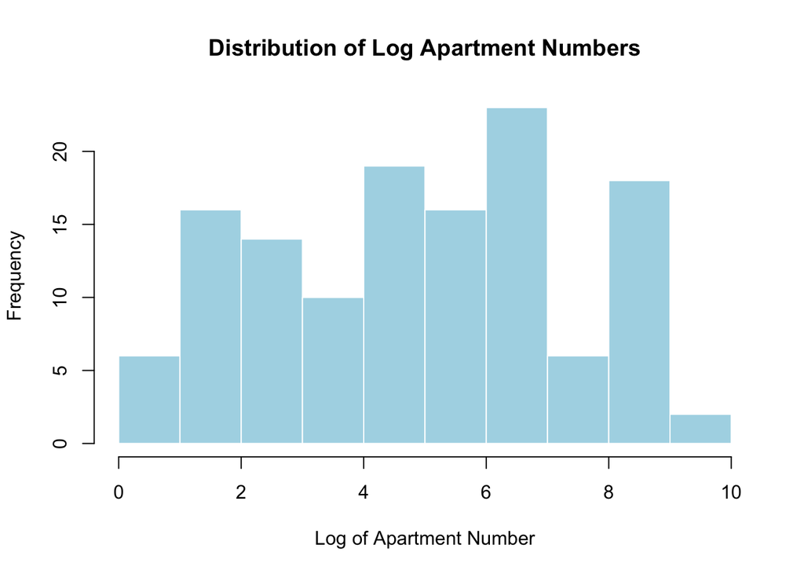

```r
# Take the natural log of apartment numbers
log_apartments <- log(apartment_numbers[apartment_numbers > 0])

# Plot the histogram
hist(
  log_apartments,
  main = "Distribution of Log Apartment Numbers",
  xlab = "Log of Apartment Number",
  ylab = "Frequency",
  col = "lightblue",
  border = "white"
)
```

Apartment numbers were extracted from the end of addresses using regular expressions. A total of 130 apartment numbers were identified. The histogram shows the distribution of their natural logarithms.

```r
# Extract the first digit of each apartment number
first_digits <- as.numeric(
  substr(as.character(apartment_numbers), 1, 1)
)

# Count the observed first digits
observed <- table(
  factor(first_digits, levels = 1:9)
)

# Calculate observed proportions
observed_prop <- as.numeric(observed) / sum(observed)

# Calculate expected proportions under Benford's Law
digits <- 1:9
benford_prop <- log10(1 + 1 / digits)

# Compare observed and expected percentages
benford_table <- data.frame(
  Digit = digits,
  Observed = round(observed_prop * 100, 2),
  Expected = round(benford_prop * 100, 2)
)

knitr::kable(
  benford_table,
  row.names = FALSE,
  col.names = c(
    "First Digit",
    "Observed (%)",
    "Benford Expected (%)"
  ),
  caption = "Observed and Expected Leading Digit Frequencies"
)
```

Observed and Expected Leading Digit Frequencies

| First Digit | Observed (%) | Benford Expected (%) |
| --- | --- | --- |
| 1 | 9.23 | 30.10 |
| 2 | 14.62 | 17.61 |
| 3 | 12.31 | 12.49 |
| 4 | 10.00 | 9.69 |
| 5 | 10.77 | 7.92 |
| 6 | 13.85 | 6.69 |
| 7 | 6.15 | 5.80 |
| 8 | 8.46 | 5.12 |
| 9 | 14.62 | 4.58 |

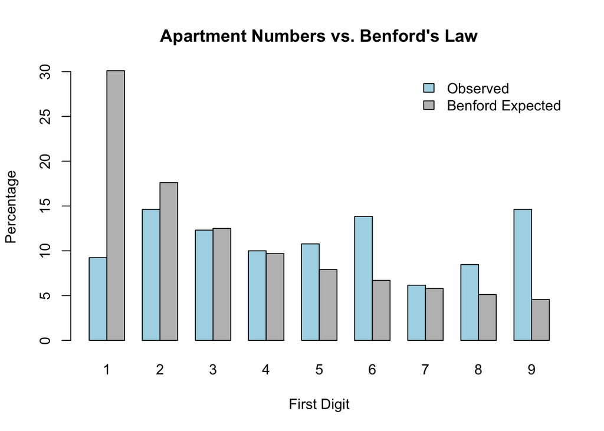

```r
# Plot observed and expected proportions
barplot(
  rbind(observed_prop, benford_prop) * 100,
  beside = TRUE,
  names.arg = digits,
  col = c("lightblue", "gray"),
  main = "Apartment Numbers vs. Benford's Law",
  xlab = "First Digit",
  ylab = "Percentage",
  legend.text = c("Observed", "Benford Expected"),
  args.legend = list(x = "topright", bty = "n")
)
```

```r
# Chi-square goodness-of-fit test
benford_test <- chisq.test(
  as.numeric(observed),
  p = benford_prop
)

# Display test results
benford_test
```

```
    Chi-squared test for given probabilities

data:  as.numeric(observed)
X-squared = 62.268, df = 8, p-value = 1.67e-10
```

The null hypothesis is that the first digits of apartment numbers follow Benford’s Law. The alternative hypothesis is that their distribution differs from Benford’s Law. The apartment numbers do not appear to follow Benford’s Law. For example, only 9.23% of the numbers begin with 1, compared with the expected 30.10%. The chi-square test gives a p-value of 1.67e-10, so we reject the null hypothesis. Based on Benford’s Law, these numbers would not pass as real data. However, apartment numbers are assigned identifiers, so they may not follow Benford’s Law even in real datasets. Therefore, this result alone cannot prove that the data are fake.